## Test a Perceptual Phenomenon

### As a general note, be sure to keep a record of any resources that you use or refer to in the creation of your project. You will need to report your sources as part of the project submission.

### 1. What is our independent variable? What is our dependent variable?

```
 ANS.  From the above background information we can see that we have an independent variables and a dependent variable.
       a) Independent Variables -> Congruency between the color of the word and word itself is independent variable.
       b) Dependent Variable -> Time it takes to name the Ink Colors,
```

### 2. What is an appropriate set of hypotheses for this task? What kind of statistical test do you expect to perform? Justify your choices.

```
 ANS.   The following hypotheses can be used to conduct a statistical test for this task:

   a). Null Hypothesis, Ho: The population mean for the completion time of congruent words is equal to the population mean              for the completion time of incongruent words (µc = µi).

   b). Alternative Hypothesis, Ha: The population mean for the completion time of congruent and incongruent words are                  different(µc≠ µi).
```

### Statistical test that can be performed on this data

#### We will perform a paired t-test on this data because:

```
  1).  We have a sample size less than 30.
  2).  We have a paired sample.
  3).  We have a normally distributed data.
```

### 3). Report some descriptive statistics regarding this dataset. Include at least one measure of central tendency and at least one measure of variability.

```python
import pandas as pd
import numpy as np

import matplotlib.pyplot as plt

%matplotlib inline
```

```python
# Read the data set
df = pd.read_csv('./data/stroopdata.csv')

# Print the shape of the data
print("Shape of the DataFrame is -> " + str(df.shape))

# Show the data
df.head(n=23) # only have 24 observation in data file
```

```
Shape of the DataFrame is -> (24, 2)
```

[output not shown]

```python
# Describe the data
df.describe()
```

|  | Congruent | Incongruent |
| --- | --- | --- |
| count | 24.000000 | 24.000000 |
| mean | 14.051125 | 22.015917 |
| std | 3.559358 | 4.797057 |
| min | 8.630000 | 15.687000 |
| 25% | 11.895250 | 18.716750 |
| 50% | 14.356500 | 21.017500 |
| 75% | 16.200750 | 24.051500 |
| max | 22.328000 | 35.255000 |

```python
# Print measures of central tendency
# mean
print("Measures of central tendency")
mean_congruent = np.mean(df['Congruent'])
mean_incongruent = np.mean(df['Incongruent'])

print("Mean of Congruent Data -> " + str(mean_congruent))
print("Mean of Incongruent Data -> " + str(mean_incongruent))
print("\n")

# Print measures of variability
# range
print("Measures of Variability")
range_congruent = np.ptp(df['Congruent'])
range_incongruent = np.ptp(df['Incongruent'])

print("Range of Congruent Data -> " + str(range_congruent))
print("Range of Incongruent Data -> " + str(range_incongruent))
print("\n")
```

```
Measures of central tendency
Mean of Congruent Data -> 14.051125
Mean of Incongruent Data -> 22.0159166667


Measures of Variability
Range of Congruent Data -> 13.698
Range of Incongruent Data -> 19.568
```

### 4). Provide one or two visualizations that show the distribution of the sample data. Write one or two sentences noting what you observe about the plot or plots.

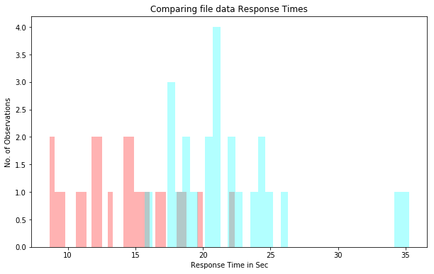

```python
fig, ax = plt.subplots(figsize=(10, 6))

ax.hist(df['Congruent'], bins = 35, color='red', alpha=0.3)
ax.hist(df['Incongruent'], bins = 35, color='cyan', alpha=0.3)

ax.set(title='Comparing file data Response Times', ylabel='No. of Observations', xlabel = 'Response Time in Sec')
ax.margins(0.05)
ax.set_ylim(bottom=0)
plt.show()
```

### 5. Now, perform the statistical test and report your results. What is your confidence level and your critical statistic value? Do you reject the null hypothesis or fail to reject it? Come to a conclusion in terms of the experiment task. Did the results match up with your expectations?

```
  We will now perform a t-test on the data to check if we have to "reject the null hypothesis" or "fail to reject the null         hypothesis".


  1). The degrees of freedom for this data is 23 as n = 24
  2). We will assume a confidence level of 90% for this 2-tailed test.
  3). Mean of Congruent data points = 14.051
  4). Mean of Incongruent data points = 22.016
  5). Standard Deviation S = 4.865 and n = 24
```

#### This falls in-line with the test results for my case wherein I took 25 seconds with Congruent condition and around 35 seconds with Incongruent condition.